# **Analysis on Graduate School Choices: Insights from Admission Trends and City Discussions**

STA 141B Final Project

Authors: Xinran Yu, Charlie Tian, Rebecca Li

```python
from google.colab import drive
drive.mount('/content/drive')
%run -i '/content/drive/MyDrive/STA141B/Copy of STA141B Final Proect.ipynb'
```

# **Introduction**

In the current academic landscape, navigating the path to graduate education is increasingly seen as a crucial step for many seeking to enhance their career prospects amid rising employment hardships. This trend leads to a surge in undergraduate students considering graduate school as a vital gateway to advanced knowledge and improved job opportunities. However, the journey toward obtaining a graduate degree is filled with anxiety and uncertainties. With the challenge of complex application processes and pressure from peers, many turn to information-sharing websites such as GradCafe for help.

The GradCafe offers prospective graduate students a collaborative space for the exchange of information, experiences, and advice, which allows them to track real-time admissions results, share their own experiences, and engage in discussions about various aspects of the graduate school application process.

This study aims to delve into the city comments and admission data available on GradCafe to uncover potential patterns and insights related to graduate school admissions, particularly Computer Science (CS) programs. Through the visualization of the admission post and analysis of city comments, this research intends to provide valuable insights that could further inform applicants' choices. This paper focuses on the following research questions:

1. What is the geographical distribution of the top 50 universities?
2. For each of the top 50 universities, what is the academic profile of admitted students?
3. What are the frequent topics for certain cities among prospective graduates students?
4. How do admission trends change before and after the COVID-19 pandemic?

Addressing these questions poses significant challenges, including the integration of multiple data sources and the meticulous organization and analysis of the collected information. By tackling these challenges, this study aims to contribute valuable insights to the field of higher education and support prospective graduate students in their journey toward academic and professional advancement.

# **Data Acquisition**

In this section, we aim to analyze the factors influencing graduate school applications, using the national university rankings from U.S. News and admission data from GradCafe.

[**U.S. News**](https://www.usnews.com/best-colleges/rankings/national-universities)

Given the vast amount of data available on the topic of graduate school admission, we must employ a focused approach to yield meaningful insights. To this end, we have opted to narrow down our database by concentrating on the top 50 ranking universities. The magazine U.S. News and World Report has been ranking U.S. universities for years and its ranking has been widely accepted. So we decided to use its national ranking as a criterion. To obtain complete data on the rankings, we found an Excel containing all the ranking data that the magazine U.S. News released each year. We then adopted the latest 2023 ranking and saved their top 50 universities' information for future use.

```python
t50_df.head(5) #the first 5 rows of the top 50 university ranking
```

|  | University Name | 2023 | State |
| --- | --- | --- | --- |
| 0 | Princeton University | 1.0 | NJ |
| 1 | Massachusetts Institute of Technology | 2.0 | MA |
| 2 | Harvard University | 3.0 | MA |
| 3 | Yale University | 3.0 | CT |
| 4 | Stanford University | 3.0 | CA |

Then, we employed documented API from Nominatim, a tool that allows for the retrieval of geographical coordinates based on place names, to find the exact locations of these top 50 universities. This function constructs a request to the API's endpoint, passing the university's name as a query parameter along with a format specification for the returned data and a limit to ensure that only the most relevant result is fetched. The response from the API, structured in JSON, provides detailed location information, including the latitude and longitude, which we then parsed to extract the necessary data. This process was iterated for each university in our list of the top 50, aggregating their location data for further analysis. After doing that, we saved all the top 50 universities' names and information in a list.

```python
t50_loc[1] #an example of from the list of university information
```

```
{'place_id': 18238156,
 'licence': 'Data © OpenStreetMap contributors, ODbL 1.0. http://osm.org/copyright',
 'osm_type': 'relation',
 'osm_id': 65066,
 'lat': '42.3582529',
 'lon': '-71.0966272383055',
 'class': 'amenity',
 'type': 'university',
 'place_rank': 30,
 'importance': 0.6467426277646406,
 'addresstype': 'amenity',
 'name': 'Massachusetts Institute of Technology',
 'display_name': 'Massachusetts Institute of Technology, Bishop Allen Drive, Central Square, Cambridgeport, Cambridge, Middlesex County, Massachusetts, 02139, United States',
 'boundingbox': ['42.3536815', '42.3652645', '-71.1100590', '-71.0817414']}
```

**GradCafe**

Multiple factors affect the choice of graduate programs, for example, the average admitted GPA and the location. It is important to determine if the program is a good fit for us by looking up the admitted students' profiles. While some programs prefer high GPAs, some programs may weigh research experience more. Considering universities do not provide a detailed admitted student profile, websites like GradCafe become a valuable source of information for prospective graduate students.

The admission data on GradCafe is presented in an HTML format, structured in a table-like layout on the webpage. Data such as school name, GPA, and other details are contained within distinct HTML tags. We identified the specific HTML structure and tags where those data are located on the page, then perform web scraping to extract all the avaliable admission data for CS programs.

After we extract all the [admission information from GradCafe](https://www.thegradcafe.com/survey/?per_page=20&q=cs&institution=&program=&degree=), we define a function that extracts and cleans information from the raw HTML structure of GradCafe pages. It distills the essence of each admission result into a structured dictionary format, containing the school's name, the date, and the decision status. Then, we perform data cleaning to the extracted data by first standardizing text to uppercase for uniformity and making sure the collected data consists solely of ASCII characters to maintain consistency.

As the data begins to accumulate, attention shifts towards more data cleaning work. Considering all the admission posts are self-reported, people may use different names or variations when referring to a particular school, which can complicate data analysis and interpretation. For example, UC Davis might be shortened to UCD, while some people write its full name as University of California, Davis. At this point, data cleaning is important to eliminate the potential discrepancy. We download a list of school names for correction and create a dictionary that maps variant names to the correct names. Then, we iterate the list and replace the school name if needed.

```python
ad_list[23] #an example of single admission post
```

```
{'School': 'Carnegie Mellon University',
 'Comment': 'My profile is as follows:- Academics:-- B.Tech. in Computer Science and Engineering from an old IIT- GPA: 9.02/10 (with full grades in Networks, ML, DSA, DBMS)- Minor in Robotics and Artificial Intelligence Experience:-- SDE internship experience at a top Silicon Valley data backup and …
 'Added Date': 'Added on March 15, 2024',
 'Decision': 'Accepted on 1 Mar',
 'Tags': ['FALL 2024', 'INTERNATIONAL', 'MASTERS']}
```

Another factor that people might consider when choosing the graduate school is the location. The location of a university is closely related to the cost of the program, available educational resources, and job opportunities. GradCafe has a discussion forum where user can ask questions and share their opinions about the cities where different universities are located. We harvested [city comments](https://forum.thegradcafe.com/forum/18-city-guide/) from the GradCafe forum for the term frequency analysis used in the next section.

We aim to collect all the user comments for the cities listed in the City Guide section on the GradCafe Forum. We first made a list containing all the URLs for all the pages so its easier to locate. Then we scraped all the comments within each city. By doing so, we were able to find the pattern of the Xpath of user comments and cleaned the data so it didn't include any advertisements on the website.

During the data collection process, we incorporates multiple functions to save the results in JSON format, facilitating structured storage and subsequent analysis.

```
#Sample code
# save_result(dir,ad_list,"admission_result_stats") #save list result to json file
```

**Challenges in Getting the Data**

We faced several challenges when performing web scraping for GradCafe, which tested the robustness and efficiency of our scraping approach.

In the context of harvesting city comments, one significant challenge encountered was the sheer volume of pages and the nested structure of the content. This forum, dedicated to discussions about different cities, is organized in a way where each city name leads to further discussions spread across multiple pages. To effectively navigate and extract information from such a complex structure, we made a nested function. The primary function is responsible for iterating through the main list of cities, while the nested function is created for navigating through the pages of discussions related to each city. This mechanism allows us to cover all the available information, ensuring that no page is left unscanned.

Harvesting admission posts from the same website presented another two notable challenges. The first major challenge stemmed from the fact that all admission posts are self-reported, leading to a lack of uniformity in how information is tagged or named. In detail, some contributor only includes the program name and the decision while others include more information such as GRE score, international students or not, and GPA. This inconsistency poses a hurdle for automated data extraction processes and challenges us to categorize a wide array of tags correctly.

To address this issue, an extensive list of possible tags was compiled to serve as a reference for data normalization. We manually inputted to create a comprehensive list that covers all the variations in naming encountered in the posts. During the scraping process, this list is then used to standardize the data, ensuring that different tags referring to the same entity are correctly identified and grouped.

Another significant challenge was the prevalence of advertisements on the website, which complicated the scraping process due to their similar XPath as the admission posts. Ads integrated into the admission results pages can easily be mistaken for genuine content, leading to the unintentional collection of irrelevant data.

To overcome this obstacle, we carefully inspected the page structure, looking for subtle differences in the HTML attributes that can help differentiate ads from actual content. As a result, a significant portion of the data cleaning effort is dedicated to identifying and removing these unwanted data points, ensuring the integrity and usability of the harvested information.

# Data Processing

In the previous section, we gathered precise location details of the top 50 universities and acquired their CS program admission data through GradCafe. Also, we performed web scraping to city comments on GradCafe. Those data provide us with ample information to carry out thorough data processing and analysis. In this section, we will integrate all the data into a data frame to make it easy to access admission data by schools and perform term frequency analysis on city comments.

By merging the exact geographical coordinates along with the admission statistics into a single data frame, we are now equipped to access and analyze all the pertinent details regarding a specific university in one go.

```python
inte_profile.head(5)
```

|  | AD_GPA | Admission rate | International ad | School | lat | lon | Address |
| --- | --- | --- | --- | --- | --- | --- | --- |
| 0 | 3.807378 | 0.290679 | 27.105263 | Princeton University | 40.338675 | -74.658365 | Princeton University, Alexander Road, Princeto... |
| 1 | NaN | NaN | NaN | Massachusetts Institute of Technology | 42.358253 | -71.096627 | Massachusetts Institute of Technology, Bishop ... |
| 2 | 3.677500 | 0.266879 | 13.263158 | Harvard University | 42.365743 | -71.122214 | Harvard University, Western Avenue, Barry's Co... |
| 3 | 3.876442 | 0.289084 | 14.105263 | Yale University | 41.257131 | -72.989670 | Yale University, West Haven, South Central Con... |
| 4 | 3.875231 | 0.238860 | 54.842105 | Stanford University | 37.431314 | -122.169365 | Stanford University, 408, Panama Mall, Stanfor... |

Next, we harvested city comments from the GradCafe forum to identify high-frequency words which allow us to analyze the topics most discussed by prospective graduate students concerning various cities. To make the result meaningful, we added a few more stopwords based on the existing English stopwords Removal package. We have selected a handful of cities that are representative of our findings and will now proceed to carefully analyze them.

```python
city_term_frequencies['Davis, CA']
```

```
FreqDist({'davis': 217, 'live': 56, 'sacramento': 43, 'town': 37, 'housing': 35, 'living': 34, 'bike': 31, 'pretty': 30, 'car': 29, 'uc': 27, ...})
```

In Davis, California, the most frequent words include Sacramento, bike, and housing. These high-frequency words paint a comprehensive picture of what prospective students prioritize and discuss the most when considering Davis as their potential graduate school location. "Sacramento" suggests a value placed on the benefits that a nearby larger city could provide, such as job opportunities, cultural experiences, or even restaurant options. The emphasis on "bike" indicates a keen interest in local transportation options and the appeal of a bike-friendly community, aligning with Davis's reputation for strong bicycle infrastructure. Additionally, the focus on "housing" highlights concerns around living arrangements and affordability, a critical factor for students when planning their graduate studies.

```python
city_term_frequencies['Camden, NJ']
```

```
FreqDist({'camden': 18, 'philly': 9, 'live': 9, 'id': 7, 'crime': 6, 'nice': 6, 'may': 6, 'haddonfield': 6, 'philadelphia': 6, 'cherry': 6, ...})
```

For prospective graduate students considering Camden, NJ, "crime" is among the most frequently mentioned words, indicating that safety and security are significant considerations for students looking into this area. This concern suggests that while evaluating potential schools, students are also thoroughly assessing the living conditions and safety of their future environments. Another frequently mentioned term is "Haddonfield," pointing to interest in nearby areas that might offer a different living experience compared to Camden itself. Sime is another frequent term for "Philly". It reflects the close relationship between Camden and the nearby larger metropolitan area.

These insights demonstrate how prospective students are not only evaluating academic programs but also carefully considering their potential living situations, safety, and the broader opportunities and lifestyle the location offers.

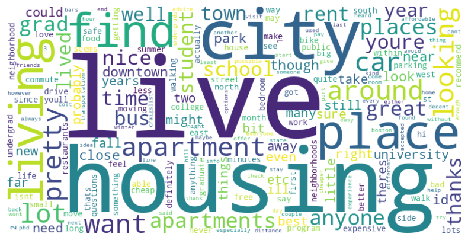

```python
# Display the generated image:
plt.figure(figsize=(10, 5))
plt.imshow(wordcloud, interpolation='bilinear')
plt.axis('off')
plt.show()
```

By creating a frequency distribution of words across all the cities that we have stored, the code iterates each word in each city and counts them. The image displayed includes the words that appear the most common. The word would appear to be larger as it appears more often. In this way, the viewers get to see more directly as the word would simply be presented and its size would imply its appearance in the City Guide section, rather than having a bar or pie graph showing numbers.

# Visualization

**Interactive Map**

Based on the data frame we made in the previous sections, we now plot an interactive map.

```python
m
```

Make this Notebook Trusted to load map: File -> Trust Notebook

[interactive chart not shown]

By zooming out on the interactive map, we can gain a comprehensive overview of the geographical spread of the top 50 universities across the United States. The majority of these prestigious institutions are concentrated along the East and West Coasts, with clusters particularly dense around metropolitan areas such as New York, Boston, and San Francisco. This visualization highlights the regional diversity of higher education institutions.

Clicking on an individual marker reveals detailed admission information for that particular university, such as the average GPA of admitted students, admission rate, and the number of admitted international students, along with the school's address. For instance, seeing the admission rate alongside the average GPA can help students evaluate their chances of acceptance and understand the competitive landscape of their desired programs. The inclusion of international student percentages also offers insights into the university's diversity and global reach. With this rich dataset at their fingertips, students can make more informed choices regarding which universities align best with their academic goals and personal preferences.

**International Student Admission and the COVID-19 Pandemic**

Considering the global impact of the COVID-19 pandemic, we are interested in the admission of international students during the era. Since governments around the world implemented restriction policies on cross-country travel, some international students may give up applying for graduate schools. However, it is hard to quantify the number of international students who give up their applications. Instead, we use the number of international students admitted.

We hypothesize that the number of international students admitted falls during the pandemic. By using the data we collected from the previous sections, we visualize the admission data and select two representative universities for analysis: Columbia University and Emory University. The graphs below each display a vertical red dashed line, indicating the onset of the pandemic, and a blue line reflecting the number of international students admitted by each university.

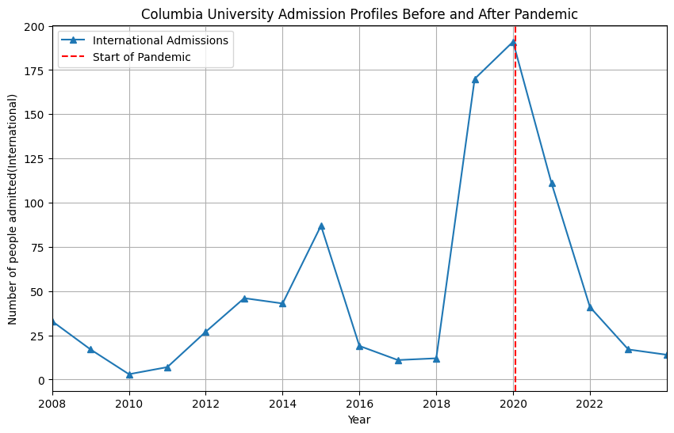

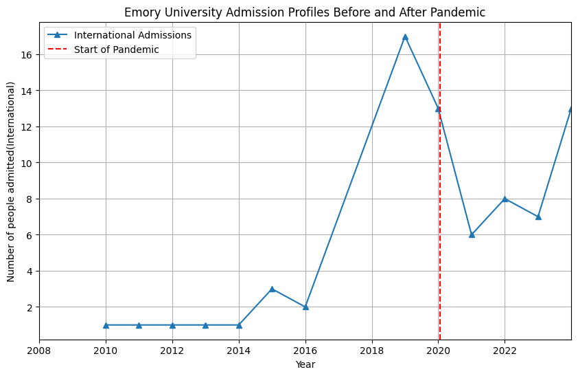

```python
plot_data(a17, t50_name[17])
plot_data(a21, t50_name[21])
```

As we can observe, there was a significant decrease in international student admissions for both universities following the pandemic, which verified our hypothesis. However, it is noteworthy that Emory University experienced a resurgence in international student admissions post-2023, which could likely be attributed to the reopening of society and the stabilization of the COVID-19 spread.

**Analysis on applicaions trend**

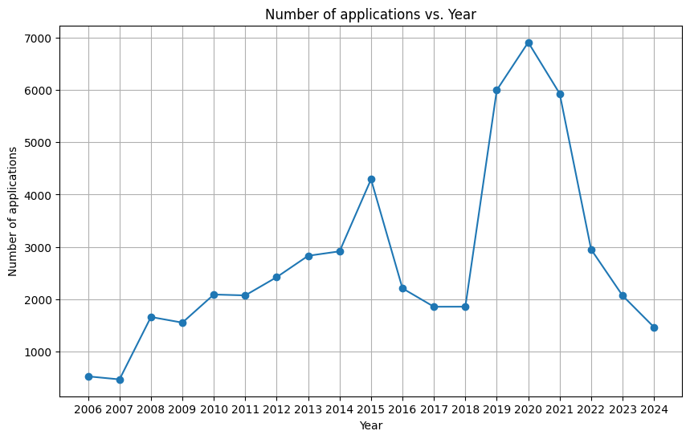

```python
plt.figure(figsize=(10, 6))
plt.plot(years, counts, marker='o')
plt.title('Number of applications vs. Year')
plt.xlabel('Year')
plt.ylabel('Number of applications')
plt.grid(True)
plt.show()
```

# Limitation

The research project, while extensive in its reach, encounters certain limitations that must be acknowledged.

Given the admission results reported on GradCafe are all self-reported, those who have been admitted are more inclined to share their success. Consequently, the data may not comprehensively represent the complete spectrum of all applicants, particularly those who were not admitted and may have opted not to report their results.

Another limitation is the temporal relevance of the city comments. The majority of these comments were posted between 2006 and 2015, rendering them potentially outdated. Changes in city dynamics, university facilities, and local economies over time mean that these comments may no longer reflect the current reality, possibly leading prospective students to make decisions based on information that is no longer accurate.

Finally, the accuracy of the geographical information presented on the interactive map is not without fault. An example of this is the incorrect location placement for the University of California, Davis (UCD), which appears west of its actual location. Such inaccuracies may mislead users about the true location of universities, affecting their perceptions and decision-making regarding prospective schools.

# Conclusion

By investigating the geographical distribution and admission profiles of the top 50 universities, analyzing discussion topics within city comments, and comparing admission trends during the pandemic, our study reveals a nuanced understanding of the graduate school application landscape.

Through an analysis of city comments, three primary concerns emerged: housing, crime, and transportation. These findings highlight the significance of living conditions and safety in the decision-making process of prospective students. In addition, the pandemic unequivocally impacted admission trends, notably leading to a decrease in the number of international students admitted.

The incorporation of interactive maps into our study provided a dynamic tool for exploring the distribution of universities and the profiles of admitted students. The map facilitated a more engaging and informative exploration of the data and provided valuable insight to students who struggling with graduate school choices.

In conclusion, our study provides a multifaceted overview of the current state of graduate school admissions. The observed trends and the dynamic shifts in the landscape, particularly in response to the COVID-19 pandemic, reflect the ongoing evolution of higher education. As universities adapt to changing circumstances and students navigate their options with increasingly sophisticated tools and information, the pursuit of graduate education continues to be a complex interplay of personal goals, academic ambitions, and practical considerations.

# Reference List

1. City Guide. (2006, March 12). The GradCafe Forums. https://forum.thegradcafe.com/forum/18-city-guide/Reiter, A. (2024, January 13).
2. Datasets | Andrew G. Reiter. https://andyreiter.com/datasets/Search - Nominatim 4.4.0 Manual. (n.d.).
3. Nominatim.org. Retrieved March 18, 2024, from https://nominatim.org/release-docs/latest/api/Search/.
4. The GradCafe. (n.d.). Www.thegradcafe.com. Retrieved March 18, 2024, from https://www.thegradcafe.com/survey/?per_page=20&q=cs&institution=&program=&degree=.

# Appendix

Please see the attached **LINK** for the code.

https://colab.research.google.com/drive/1k3zpOxtsLurJsPEpTtngUGRVyhr8PTqc?usp=drive_link#scrollTo=PZpcIgf3vyKM

```python
#export as html
%%shell
jupyter nbconvert --to html '/content/drive/MyDrive/STA141B/STA141B Final project REPORT.ipynb'
```